# URBAN5127 | M3 interaction model — 8-category density × 3-category vehicle interaction

2022 NextGen NHTS · independent follow-up to Formative 1

> **用途 / Purpose.** 本文是配合 `3281675Z_URBAN5127_Formative_1.Rmd` 的独立后续分析脚本，**不是替代原始形成性作业的提交稿**。它直接复用原文件生成的 `analysis_data.rds`，不会再次筛选原始旅程或覆盖任何旧结果。导出结果用于比较模型与向老师讨论建模选择。

> **路径 / Path.** 你的原始 Rmd 使用 `../data/processed/analysis_data.rds`；把本文件放在和原 Rmd **同一个项目文件夹**后点击 *Knit*。若文件放在别的目录，在顶部 `params: data_path:` 中修改数据路径。请先运行原始 Rmd 的数据清洗部分，确保 RDS 已生成。

> **统计口径.** 每行一位成年出行者；`mean_trip_miles` 为每位受访者调查日的**平均每次**行程距离（英里），不是每日总里程。以下是未加权 OLS 的样本内条件关联，不构成因果估计；如需全国总体推断，未来应考虑 NHTS 抽样设计及权重。

# 1 1. 加载包和第四阶段数据

```r
need <- c("tidyverse", "broom", "knitr")
missing <- need[!vapply(need, requireNamespace, logical(1), quietly = TRUE)]
if (length(missing)) stop("请先安装 R 包 / Install packages: ", paste(missing, collapse = ", "))
library(tidyverse)
library(broom)
library(knitr)

if (!file.exists(params$data_path)) {
  stop("未找到清洗数据：", params$data_path,
       "\n请先运行原始 Formative Rmd 中的 saveRDS(analysis_data, '../data/processed/analysis_data.rds')，",
       "并确保本文件与原始 Rmd 在同一目录，或修改 YAML 中 params$data_path。")
}
analysis_data <- readRDS(params$data_path)
out_dir <- params$output_dir
dir.create(out_dir, recursive = TRUE, showWarnings = FALSE)
```

## 1.1 1.1 按原始代码的实际变量名构建统一样本

原始 Rmd 的字段名是 `HTPPOPDN`、`WORKER`、`TRAVDAY`、`vehicles`、`hh_size`、`age`、`mean_trip_miles` 和 `HOUSEID`，**不是**先前讨论中的 `worker` / `day_of_week` 等假定列。以下由这些真实字段生成回归因子，四档和八档方案均使用**完全相同的建模样本**。

```r
required <- c("HOUSEID", "PERSONID", "mean_trip_miles", "HTPPOPDN",
              "age", "hh_size", "vehicles", "WORKER", "TRAVDAY")
absent <- setdiff(required, names(analysis_data))
if (length(absent)) stop("analysis_data.rds 缺少字段：", paste(absent, collapse = ", "))

model_data <- analysis_data |>
  transmute(
    HOUSEID = as.character(HOUSEID),
    PERSONID = as.character(PERSONID),
    mean_trip_miles = as.numeric(mean_trip_miles),
    density_code = sprintf("%02d", as.integer(as.character(HTPPOPDN))),
    age = as.numeric(age),
    hh_size = as.numeric(hh_size),
    vehicles = as.numeric(vehicles),
    WORKER = as.character(WORKER),
    TRAVDAY = as.character(TRAVDAY)
  ) |>
  filter(
    is.finite(mean_trip_miles), mean_trip_miles >= 0,
    is.finite(age), age >= 18,
    is.finite(hh_size), hh_size > 0,
    is.finite(vehicles), vehicles >= 0,
    density_code %in% sprintf("%02d", 1:8),
    WORKER %in% c("01", "02"),
    TRAVDAY %in% sprintf("%02d", 1:7)
  ) |>
  mutate(
    density_8 = factor(paste0("D", as.integer(density_code)),
                       levels = paste0("D", 1:8)),
    density_4 = factor(case_when(
      density_code %in% c("01", "02") ~ "D1",
      density_code %in% c("03", "04") ~ "D2",
      density_code %in% c("05", "06") ~ "D3",
      density_code %in% c("07", "08") ~ "D4"
    ), levels = paste0("D", 1:4)),
    car_group = factor(case_when(
      vehicles == 0 ~ "0 vehicles",
      vehicles == 1 ~ "1 vehicle",
      vehicles >= 2 ~ "2+ vehicles"
    ), levels = c("1 vehicle", "0 vehicles", "2+ vehicles")),
    worker = factor(WORKER, levels = c("02", "01"),
                    labels = c("Non-worker", "Worker")),
    survey_day = factor(TRAVDAY, levels = sprintf("%02d", 1:7)),
    age_c = age - mean(age)
  ) |>
  tidyr::drop_na(HOUSEID, PERSONID, mean_trip_miles,
                 density_8, density_4, car_group, worker, survey_day, age_c, hh_size)

stopifnot(nrow(model_data) == n_distinct(model_data$HOUSEID, model_data$PERSONID))
sample_audit <- tibble(
  Item = c("原始清洗样本人数", "当前共同回归样本人数", "不同家庭数", "缺失/无效而被排除的人数"),
  Value = c(nrow(analysis_data), nrow(model_data),
            n_distinct(model_data$HOUSEID), nrow(analysis_data)-nrow(model_data))
)
knitr::kable(sample_audit, caption = "Sample audit: shared regression sample")
```

Sample audit: shared regression sample

| Item | Value |
| --- | --- |
| 原始清洗样本人数 | 9052 |
| 当前共同回归样本人数 | 9052 |
| 不同家庭数 | 6113 |
| 缺失/无效而被排除的人数 | 0 |

```r
if (nrow(model_data) != 9052L) {
  warning("当前样本数不是此前核验的 9,052。请核对原始清洗对象；不要直接假定两次分析相同。")
}
```

# 2 2. 模型的共同基线 M0–M2（原始八档）

参考组：密度 `D1`（0–99 人/平方英里）、**1 vehicle**、**Non-worker**、调查日代码 `01`。`age_c = 0` 对应样本平均年龄。`WORKER='01'` 编码为 Worker、`WORKER='02'` 编码为 Non-worker；调查日维持原始 `TRAVDAY` 分类编码，避免擅自指定星期名称。

```r
m0 <- lm(mean_trip_miles ~ age_c + I(age_c^2) + worker + hh_size + survey_day,
         data = model_data)
m1_8 <- update(m0, . ~ . + density_8)
m2_8 <- update(m1_8, . ~ . + car_group)

stopifnot(nobs(m0) == nrow(model_data), nobs(m1_8) == nrow(model_data),
          nobs(m2_8) == nrow(model_data))

baseline_fit <- purrr::imap_dfr(
  list(M0 = m0, M1_8 = m1_8, M2_8 = m2_8),
  ~ broom::glance(.x) |> mutate(Model = .y, .before = 1)
) |>
  select(Model, nobs, r.squared, adj.r.squared, sigma, AIC, BIC)
knitr::kable(baseline_fit, digits = 4, caption = "Baseline model comparison")
```

Baseline model comparison

| Model | nobs | r.squared | adj.r.squared | sigma | AIC | BIC |
| --- | --- | --- | --- | --- | --- | --- |
| M0 | 9052 | 0.0044 | 0.0033 | 71.2044 | 102925.1 | 103010.4 |
| M1_8 | 9052 | 0.0071 | 0.0052 | 71.1378 | 102915.1 | 103050.2 |
| M2_8 | 9052 | 0.0091 | 0.0070 | 71.0743 | 102900.9 | 103050.2 |

```r
# 这两个比较严格嵌套，且使用相同观测
a_01 <- anova(m0, m1_8)
a_12 <- anova(m1_8, m2_8)
knitr::kable(as.data.frame(a_01), digits = 4, caption = "M0 vs M1 (8 density groups)")
```

M0 vs M1 (8 density groups)

| Res.Df | RSS | Df | Sum of Sq | F | Pr(>F) |
| --- | --- | --- | --- | --- | --- |
| 9041 | 45838496 | NA | NA | NA | NA |
| 9034 | 45717395 | 7 | 121101.4 | 3.4186 | 0.0012 |

```r
knitr::kable(as.data.frame(a_12), digits = 4, caption = "M1 vs M2 (vehicle ownership)")
```

M1 vs M2 (vehicle ownership)

| Res.Df | RSS | Df | Sum of Sq | F | Pr(>F) |
| --- | --- | --- | --- | --- | --- |
| 9034 | 45717395 | NA | NA | NA | NA |
| 9032 | 45625601 | 2 | 91793.92 | 9.0857 | 1e-04 |

# 3 3. 密度 × 家庭车辆数交叉样本检查

**不能只看整体 9,052 人。** 要先检查每一个密度与汽车拥有量组合的人数和不同家庭数。以下人数为未加权的受访者数量；`< 20` 仅用于**提示**稀疏单元，并不是正式的统计学硬阈值。

```r
cell_support <- model_data |>
  group_by(density_8, car_group, .drop = FALSE) |>
  summarise(
    persons = n(),
    households = n_distinct(HOUSEID),
    .groups = "drop"
  ) |>
  rename(density = density_8) |>
  mutate(
    sparse_20 = persons < 20,
    label = paste0(persons, "\n(", households, " HH)")
  )
knitr::kable(cell_support |> select(-label), caption = "Cell support: persons and distinct households")
```

Cell support: persons and distinct households

| density | car_group | persons | households | sparse_20 |
| --- | --- | --- | --- | --- |
| D1 | 1 vehicle | 189 | 167 | FALSE |
| D1 | 0 vehicles | 6 | 6 | TRUE |
| D1 | 2+ vehicles | 944 | 599 | FALSE |
| D2 | 1 vehicle | 241 | 210 | FALSE |
| D2 | 0 vehicles | 16 | 14 | TRUE |
| D2 | 2+ vehicles | 1073 | 665 | FALSE |
| D3 | 1 vehicle | 168 | 146 | FALSE |
| D3 | 0 vehicles | 10 | 9 | TRUE |
| D3 | 2+ vehicles | 594 | 358 | FALSE |
| D4 | 1 vehicle | 259 | 228 | FALSE |
| D4 | 0 vehicles | 18 | 17 | TRUE |
| D4 | 2+ vehicles | 995 | 604 | FALSE |
| D5 | 1 vehicle | 436 | 373 | FALSE |
| D5 | 0 vehicles | 40 | 35 | FALSE |
| D5 | 2+ vehicles | 1440 | 878 | FALSE |
| D6 | 1 vehicle | 573 | 463 | FALSE |
| D6 | 0 vehicles | 76 | 61 | FALSE |
| D6 | 2+ vehicles | 1271 | 770 | FALSE |
| D7 | 1 vehicle | 208 | 164 | FALSE |
| D7 | 0 vehicles | 27 | 25 | FALSE |
| D7 | 2+ vehicles | 203 | 126 | FALSE |
| D8 | 1 vehicle | 124 | 88 | FALSE |
| D8 | 0 vehicles | 93 | 79 | FALSE |
| D8 | 2+ vehicles | 48 | 28 | FALSE |

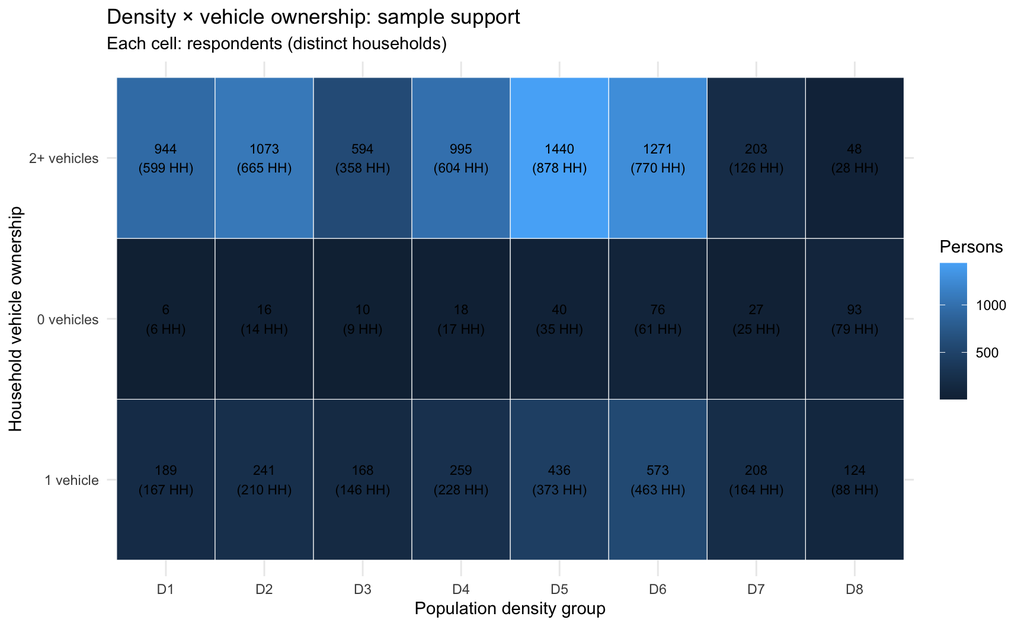

```r
write_csv(cell_support |> select(-label), file.path(out_dir, "cell_support.csv"))

p_support <- ggplot(cell_support,
                    aes(x = density, y = car_group, fill = persons)) +
  geom_tile(colour = "white") +
  geom_text(aes(label = label), size = 3) +
  labs(
    title = "Density × vehicle ownership: sample support",
    subtitle = "Each cell: respondents (distinct households)",
    x = "Population density group", y = "Household vehicle ownership", fill = "Persons"
  ) + theme_minimal(base_size = 11)
print(p_support)
```

```r
ggsave(file.path(out_dir, "cell_support_heatmap.png"), p_support,
       width = 8.5, height = 4.6, dpi = 300)
if (any(cell_support$persons == 0L)) warning("存在无观测交叉组：交互模型可能秩亏，勿解释对应系数或进行外推。")
if (any(cell_support$sparse_20)) {
  cat("**提示：** 下表显示样本数少于20的交叉组合。可能出现较大标准误及对少数受访者敏感的交互估计。\n\n")
  print(knitr::kable(cell_support |> filter(sparse_20) |> select(-label)))
}
```

```
## **提示：** 下表显示样本数少于20的交叉组合。可能出现较大标准误及对少数受访者敏感的交互估计。
##
##
##
## |density |car_group  | persons| households|sparse_20 |
## |:-------|:----------|-------:|----------:|:---------|
## |D1      |0 vehicles |       6|          6|TRUE      |
## |D2      |0 vehicles |      16|         14|TRUE      |
## |D3      |0 vehicles |      10|          9|TRUE      |
## |D4      |0 vehicles |      18|         17|TRUE      |
```

# 4 4. 方案 B：八档人口密度交互模型

八档密度直接与三档车辆组交互，共有 24 个交叉组合；相比 `M2_8`，完整列秩时会新增 `(8-1)×(3-1)=14` 个交互系数。

这里 M2 与 M3 使用**同一份八档编码、同样的样本、相同主效应**，因此可直接进行嵌套模型比较。

```r
m3_8 <- update(m2_8, . ~ . + density_8:car_group)

stopifnot(nobs(m3_8) == nobs(m2_8), nobs(m3_8) == nrow(model_data))
rank_ok <- m3_8$rank == length(coef(m3_8)) && !anyNA(coef(m3_8))
cat("M3_8 full rank / 模型满秩：", rank_ok, "\n")
```

```
## M3_8 full rank / 模型满秩： TRUE
```

```r
if (!rank_ok) {
  cat("交互模型存在无法单独估计的系数。请先检查空交叉单元与 alias(m3_8)。\n")
  print(alias(m3_8))
}
knitr::kable(broom::glance(m2_8) |> mutate(Model="M2_8",.before=1) |>
               bind_rows(broom::glance(m3_8) |> mutate(Model="M3_8",.before=1)) |>
               select(Model,nobs,r.squared,adj.r.squared,sigma,AIC,BIC),
             digits=4, caption="Matched eight-group model comparison")
```

Matched eight-group model comparison

| Model | nobs | r.squared | adj.r.squared | sigma | AIC | BIC |
| --- | --- | --- | --- | --- | --- | --- |
| M2_8 | 9052 | 0.0091 | 0.0070 | 71.0743 | 102900.9 | 103050.2 |
| M3_8 | 9052 | 0.0100 | 0.0064 | 71.0961 | 102920.5 | 103169.3 |

```r
nested_test <- anova(m2_8, m3_8)
knitr::kable(as.data.frame(nested_test), digits=4,
             caption="Joint conventional F-test: fourteen eight-group interaction terms")
```

Joint conventional F-test: fourteen eight-group interaction terms

| Res.Df | RSS | Df | Sum of Sq | F | Pr(>F) |
| --- | --- | --- | --- | --- | --- |
| 9032 | 45625601 | NA | NA | NA | NA |
| 9018 | 45582947 | 14 | 42654.31 | 0.6028 | 0.8652 |

```r
coefs_m3 <- broom::tidy(m3_8, conf.int = TRUE)
knitr::kable(coefs_m3, digits=4, caption="M3_8 coefficient estimates (conventional OLS)")
```

M3_8 coefficient estimates (conventional OLS)

| term | estimate | std.error | statistic | p.value | conf.low | conf.high |
| --- | --- | --- | --- | --- | --- | --- |
| (Intercept) | 24.1622 | 5.8046 | 4.1626 | 0.0000 | 12.7840 | 35.5405 |
| age_c | -0.1050 | 0.0539 | -1.9473 | 0.0515 | -0.2107 | 0.0007 |
| I(age_c^2) | -0.0034 | 0.0027 | -1.2654 | 0.2057 | -0.0086 | 0.0019 |
| workerWorker | 0.0311 | 1.8230 | 0.0171 | 0.9864 | -3.5425 | 3.6046 |
| hh_size | -1.4670 | 0.6525 | -2.2484 | 0.0246 | -2.7460 | -0.1880 |
| survey_day02 | -7.7354 | 2.5557 | -3.0267 | 0.0025 | -12.7452 | -2.7256 |
| survey_day03 | -12.2595 | 2.7326 | -4.4863 | 0.0000 | -17.6161 | -6.9029 |
| survey_day04 | -11.8685 | 2.8060 | -4.2296 | 0.0000 | -17.3689 | -6.3680 |
| survey_day05 | -13.2592 | 2.7739 | -4.7799 | 0.0000 | -18.6967 | -7.8216 |
| survey_day06 | -6.7910 | 2.7524 | -2.4673 | 0.0136 | -12.1863 | -1.3957 |
| survey_day07 | -3.2522 | 2.9563 | -1.1001 | 0.2713 | -9.0472 | 2.5428 |
| density_8D2 | 4.6071 | 6.9142 | 0.6663 | 0.5052 | -8.9463 | 18.1606 |
| density_8D3 | -2.5756 | 7.5420 | -0.3415 | 0.7327 | -17.3595 | 12.2084 |
| density_8D4 | -1.6196 | 6.8059 | -0.2380 | 0.8119 | -14.9607 | 11.7216 |
| density_8D5 | 4.1541 | 6.1952 | 0.6705 | 0.5025 | -7.9900 | 16.2981 |
| density_8D6 | 2.4751 | 5.9666 | 0.4148 | 0.6783 | -9.2208 | 14.1711 |
| density_8D7 | 0.9708 | 7.1560 | 0.1357 | 0.8921 | -13.0565 | 14.9982 |
| density_8D8 | -1.6901 | 8.2243 | -0.2055 | 0.8372 | -17.8116 | 14.4313 |
| car_group0 vehicles | -3.7015 | 29.4986 | -0.1255 | 0.9001 | -61.5255 | 54.1225 |
| car_group2+ vehicles | 12.4990 | 5.6914 | 2.1961 | 0.0281 | 1.3425 | 23.6555 |
| density_8D2:car_group0 vehicles | -5.8391 | 34.7479 | -0.1680 | 0.8666 | -73.9529 | 62.2746 |
| density_8D3:car_group0 vehicles | 5.0704 | 37.4984 | 0.1352 | 0.8924 | -68.4349 | 78.5757 |
| density_8D4:car_group0 vehicles | -2.4830 | 34.2076 | -0.0726 | 0.9421 | -69.5376 | 64.5717 |
| density_8D5:car_group0 vehicles | -9.9602 | 31.7567 | -0.3136 | 0.7538 | -72.2105 | 52.2901 |
| density_8D6:car_group0 vehicles | -6.3229 | 30.7501 | -0.2056 | 0.8371 | -66.6001 | 53.9542 |
| density_8D7:car_group0 vehicles | -7.3024 | 32.8842 | -0.2221 | 0.8243 | -71.7628 | 57.1581 |
| density_8D8:car_group0 vehicles | -4.3334 | 31.0765 | -0.1394 | 0.8891 | -65.2504 | 56.5835 |
| density_8D2:car_group2+ vehicles | -2.6936 | 7.6108 | -0.3539 | 0.7234 | -17.6125 | 12.2253 |
| density_8D3:car_group2+ vehicles | -3.1101 | 8.4131 | -0.3697 | 0.7116 | -19.6016 | 13.3814 |
| density_8D4:car_group2+ vehicles | 0.8563 | 7.5374 | 0.1136 | 0.9096 | -13.9188 | 15.6314 |
| density_8D5:car_group2+ vehicles | -10.1780 | 6.8768 | -1.4800 | 0.1389 | -23.6581 | 3.3021 |
| density_8D6:car_group2+ vehicles | -9.8916 | 6.7026 | -1.4758 | 0.1400 | -23.0301 | 3.2470 |
| density_8D7:car_group2+ vehicles | -15.2203 | 9.0245 | -1.6866 | 0.0917 | -32.9103 | 2.4697 |
| density_8D8:car_group2+ vehicles | 1.8736 | 13.3534 | 0.1403 | 0.8884 | -24.3022 | 28.0493 |

```r
write_csv(coefs_m3, file.path(out_dir,"M3_8_coefficients.csv"))
```

原始数据中有同一家庭的多个成年人。常规 `summary(lm)` / `anova()` 的标准误及 F 检验没有自动处理家庭内误差相关。下面在安装 `sandwich`、`lmtest`、`car` 后进一步做**按 HOUSEID 聚类**的系数与交互项联合检验。缺少可选包时不影响其他代码 Knit；但必须在论文中区分普通检验与聚类稳健检验。家庭聚类**不等于** NHTS 全套抽样设计加权推断。

```r
robust_available <- all(vapply(c("sandwich", "lmtest", "car"),
                               requireNamespace, logical(1), quietly = TRUE))
V_pred <- stats::vcov(m3_8)
uncertainty_label <- "Conventional OLS 95% CI"

if (robust_available && rank_ok) {
  # 已保证 lm 使用了 model_data 的全部行，因此此向量与模型残差顺序一致
  V_cluster <- sandwich::vcovCL(m3_8, cluster = model_data$HOUSEID, type = "HC1")
  print(lmtest::coeftest(m3_8, vcov. = V_cluster))
  term_names <- names(coef(m3_8))
  interaction_names <- term_names[grepl(":", term_names, fixed = TRUE)]
  R <- diag(length(term_names))
  colnames(R) <- term_names
  rownames(R) <- term_names
  R <- R[interaction_names, , drop = FALSE]
  joint_robust <- car::linearHypothesis(
    m3_8, hypothesis.matrix = R, rhs = rep(0, nrow(R)),
    vcov. = V_cluster, test = "F"
  )
  print(joint_robust)
  V_pred <- V_cluster
  uncertainty_label <- "Household-clustered 95% CI (normal approximation)"
} else {
  cat("未进行家庭聚类联合检验：请安装 sandwich, lmtest, car，且确保 M3 无秩亏。\n")
}
```

```
## 未进行家庭聚类联合检验：请安装 sandwich, lmtest, car，且确保 M3 无秩亏。
```

# 5 6. 调整后的预测均值：人口密度 × 车辆组

下图的预测值采用**样本标准化（g-computation 式的描述性标准化）**：对每一个密度×车辆组合，保持全部观测的年龄、就业、家庭规模及调查日分布不变，只把密度和车辆组设置为对应组合，计算预测均值后取平均。这是模型上的**条件关联比较**，不是因果效应，也不是原始样本每格的实际均值。

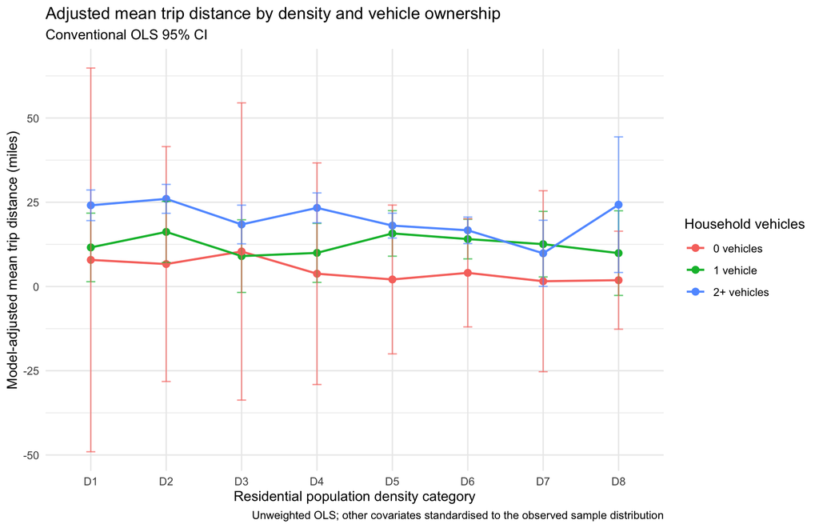

```r
if (rank_ok && all(cell_support$persons > 0L)) {
  predictions <- tidyr::expand_grid(
    density = levels(model_data$density_8),
    car = levels(model_data$car_group)
  ) |>
    purrr::pmap_dfr(function(density, car) {
      nd <- model_data
      nd$density_8 <- factor(rep(density, nrow(nd)),
                                levels = levels(model_data$density_8))
      nd$car_group <- factor(rep(car, nrow(nd)),
                              levels = levels(model_data$car_group))
      X <- model.matrix(stats::delete.response(stats::terms(m3_8)), data = nd,
                        contrasts.arg = m3_8$contrasts)
      b <- coef(m3_8)
      if (!identical(colnames(X), names(b))) {
        stop("预测设计矩阵与回归系数列名不匹配；请检查变量编码。")
      }
      xbar <- colMeans(X)
      estimate <- sum(xbar * b)
      se <- sqrt(drop(crossprod(xbar, V_pred %*% xbar)))
      tibble(density = density, car_group = car,
             adjusted_mean = estimate, se = se,
             low = estimate - 1.96 * se,
             high = estimate + 1.96 * se)
    })

  p_interact <- ggplot(predictions,
                       aes(x = density, y = adjusted_mean,
                           colour = car_group, group = car_group)) +
    geom_line(linewidth = 0.8) + geom_point(size = 2.3) +
    geom_errorbar(aes(ymin = low, ymax = high), width = 0.12, alpha = 0.65) +
    labs(title = "Adjusted mean trip distance by density and vehicle ownership",
         subtitle = uncertainty_label,
         x = "Residential population density category",
         y = "Model-adjusted mean trip distance (miles)",
         colour = "Household vehicles",
         caption = "Unweighted OLS; other covariates standardised to the observed sample distribution") +
    theme_minimal(base_size = 11)
  print(p_interact)
  ggsave(file.path(out_dir, "M3_adjusted_predictions.png"), p_interact,
         width = 9, height = 5.7, dpi = 300)
  write_csv(predictions, file.path(out_dir, "M3_adjusted_predictions.csv"))
} else {
  cat("跳过调整后预测图：存在空交叉组或模型秩亏，不能可靠推断所有组合。\n")
}
```

# 6 7. 诊断：极端值、异方差、模型设定与影响力

你的原始 `mean_trip_miles` 右偏且含有效的零值，使用原始英里 OLS 时尤其要关注极端距离；**不要为了让模型显著随意删除观测**。本节保留原始数据，只做诊断。

```r
cat("残差标准误：", summary(m3_8)$sigma, "\n")
```

```
## 残差标准误： 71.09615
```

```r
cat("负预测数量：", sum(fitted(m3_8) < 0), "\n")
```

```
## 负预测数量： 76
```

```r
cd <- cooks.distance(m3_8)
cat("Cook's D > 4/n 的观测数：", sum(cd > 4/nobs(m3_8), na.rm=TRUE), "\n")
```

```
## Cook's D > 4/n 的观测数： 132
```

```r
if (requireNamespace("lmtest", quietly = TRUE)) {
  print(lmtest::bptest(m3_8))
  print(lmtest::resettest(m3_8, power=2:3, type="fitted"))
} else {
  cat("需安装 lmtest 才能运行 BP 与 RESET 检验。\n")
}
```

```
## 需安装 lmtest 才能运行 BP 与 RESET 检验。
```

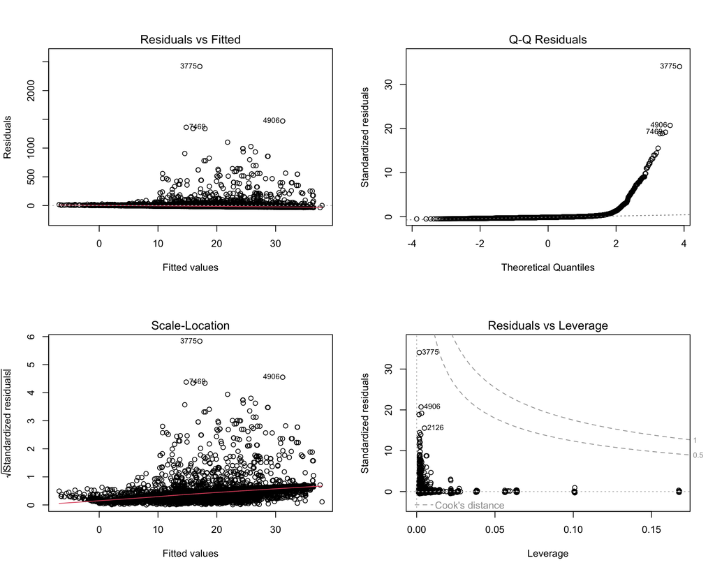

```r
par(mfrow = c(2,2))
plot(m3_8, which = 1)
plot(m3_8, which = 2)
plot(m3_8, which = 3)
plot(m3_8, which = 5)
```

```r
par(mfrow = c(1,1))
```

# 7 8. 导出模型和对老师讨论的结论框架

```r
model_bundle <- list(M0=m0, M1_8=m1_8, M2_8=m2_8, M3_8=m3_8)
saveRDS(model_bundle, file.path(out_dir, "regression_models.rds"))
write_csv(baseline_fit, file.path(out_dir, "baseline_model_fit.csv"))
write_csv(broom::glance(m3_8), file.path(out_dir, "M3_model_fit.csv"))
write_csv(tibble(term=names(coef(m3_8)),estimate=unname(coef(m3_8))),
          file.path(out_dir, "M3_parameters.csv"))
cat("全部结果输出到：", normalizePath(out_dir), "\n")
```

```
## 全部结果输出到： /Users/pippin/Documents/Code/URBAN5127_NHTS/R/M3_eight_group_results
```

## 7.1 如何解释结果 / Interpretation checklist

1. 首先检查交叉单元的人数与独立家庭数：零单元、样本非常稀少的单元，以及参考组是否可靠。
2. 报告匹配的非交互模型与交互模型比较中**整体交互项联合检验**的 F、自由度和 p 值，不要只挑显著的单项交互。
3. 比较调整后的预测均值和置信区间；结果表现出起伏不等于有显著交互，必须与联合检验一致讨论。
4. 对同时来自一个家庭的多个受访者，优先检查按家庭聚类的推断；考虑 NHTS 权重时应另行开展调查设计分析。
5. 报告诊断结果及局限：模型是观察性、未加权 OLS，不能将人口密度的系数解释为因果作用。

## 7.2 两个方案的取舍 / How to choose

**八档 M3 的优势**：与八档的 M1、M2 使用完全一致的密度编码，使 `M2_8 → M3_8` 成为直接嵌套比较，并保留更细的密度分组；**代价**：14 个额外交互项、部分非常稀疏的交叉组合，标准误与影响点敏感性可能更严重。建议检查家庭数、联合检验和高影响观测，并与四档方案的结论做敏感性比较，而不是仅以原始 R² 较高选择复杂模型。